# How is property tax calculated in New York

1. The market value of the house is estimated. The Department of Finance is responsible for doing so.
2. Multiply the estimated market value by the level of assessment,î which is 6% (Tax Class 1) or 45% (all other classes).

## Different class buildings in New York

- Class 1:

  > Assessed Value (AV) cannot increase more than 6 percent each year or more than 20 percent in five years.
- Class 2:

  > Assessed Value (AV) cannot increase more than 8 percent each year or more than 30 percent in five years.

Usually property tax is calculated once every 5 years.

The challenge faced by the Municipal Corporation is that they are citizens are challenging the assessment of property taxes and is criticized for complicated assessment procedure system as well as multiple required filings throughout the year to challenge one’s assessment.

The idea is to tackle this with Machine Learning.

### How Machine Learning can help?

A predictive model can be built to automating the property valuation process, hence reducing the unfairness within the tax system.

```python
#importing the required libraries
import pandas as pd
import numpy as np
import matplotlib.pyplot as plt
import warnings
warnings.filterwarnings('ignore')
```

```python
#reading the file
df = pd.read_excel('Train.xlsx')
```

```python
#checking the shape of the dataframe
df.shape
```

```
(16810, 19)
```

```python
#Summary of the dataset
df.describe()
```

|  | Borough | ZipCode | Block | Lot | NoOfResidentialUnits | NoOfCommercialUnits | TotalNoOfUnits | LandAreaInSqFt | GrossAreaInSqFt | YearOfConstruction | TaxClass_AtEvaluationTime | PropertyEvaluationvalue |
| --- | --- | --- | --- | --- | --- | --- | --- | --- | --- | --- | --- | --- |
| count | 16810.000000 | 16810.000000 | 16810.000000 | 16810.000000 | 16810.000000 | 16810.000000 | 16810.000000 | 1.681000e+04 | 1.681000e+04 | 16810.000000 | 16810.000000 | 1.681000e+04 |
| mean | 3.439143 | 10871.027543 | 5428.122308 | 266.327722 | 1.862225 | 0.137775 | 2.000000 | 1.092492e+04 | 3.612157e+03 | 1973.982867 | 1.289530 | 8.084101e+05 |
| std | 1.398950 | 522.996869 | 3710.031921 | 542.420132 | 8.027805 | 2.185857 | 8.472771 | 5.837620e+04 | 1.627378e+04 | 23.632595 | 0.713779 | 8.978317e+05 |
| min | 1.000000 | 10001.000000 | 6.000000 | 1.000000 | 0.000000 | 0.000000 | 1.000000 | 1.000000e+00 | 1.000000e+00 | 1941.000000 | 1.000000 | 1.000440e+05 |
| 25% | 2.000000 | 10312.000000 | 2401.250000 | 25.000000 | 1.000000 | 0.000000 | 1.000000 | 2.100000e+03 | 1.224000e+03 | 1951.000000 | 1.000000 | 4.250000e+05 |
| 50% | 3.000000 | 11207.000000 | 5050.000000 | 52.000000 | 1.000000 | 0.000000 | 1.000000 | 3.200000e+03 | 1.750000e+03 | 1968.000000 | 1.000000 | 5.900000e+05 |
| 75% | 5.000000 | 11364.000000 | 7376.750000 | 138.000000 | 2.000000 | 0.000000 | 2.000000 | 5.000000e+03 | 2.449750e+03 | 1998.000000 | 1.000000 | 8.450000e+05 |
| max | 5.000000 | 11694.000000 | 16314.000000 | 5323.000000 | 437.000000 | 252.000000 | 437.000000 | 5.612000e+06 | 1.172005e+06 | 2012.000000 | 4.000000 | 9.935000e+06 |

```python
#displaying first 5 rows
df.head(5)
```

|  | PropertyID | Borough | State | Surroundings | Address | ZipCode | Block | Lot | BldgClassCategory | NoOfResidentialUnits | NoOfCommercialUnits | TotalNoOfUnits | LandAreaInSqFt | GrossAreaInSqFt | YearOfConstruction | TaxClass_AtEvaluationTime | BldgClass_AtEvaluationTime | DateOfEvaluation | PropertyEvaluationvalue |
| --- | --- | --- | --- | --- | --- | --- | --- | --- | --- | --- | --- | --- | --- | --- | --- | --- | --- | --- | --- |
| 0 | PR11101 | 1 | NY | BATHGATE | 1473 CROTONA PLACE | 10456 | 2927 | 127 | 02 TWO FAMILY DWELLINGS | 2 | 0 | 2 | 1900 | 2394 | 1990 | 1 | B1 | 2014-05-30 | 540000 |
| 1 | PR11102 | 1 | NY | BATHGATE | 453 EAST 181 | 10457 | 3037 | 110 | 03 THREE FAMILY DWELLINGS | 3 | 0 | 3 | 1687 | 3037 | 2002 | 1 | C0 | 2014-09-13 | 750000 |
| 2 | PR11103 | 1 | NY | BATHGATE | 511 EAST 171 STREET | 10457 | 2912 | 155 | 02 TWO FAMILY DWELLINGS | 2 | 0 | 2 | 2000 | 2400 | 1989 | 1 | B1 | 2014-09-28 | 470000 |
| 3 | PR11104 | 1 | NY | BATHGATE | 547 CLAREMONT PARKWAY | 10457 | 2929 | 134 | 02 TWO FAMILY DWELLINGS | 2 | 0 | 2 | 2356 | 2394 | 1991 | 1 | B1 | 2014-06-05 | 570000 |
| 4 | PR11105 | 1 | NY | BATHGATE | 2063 WASHINGTON AVENUE | 10457 | 3036 | 140 | 02 TWO FAMILY DWELLINGS | 2 | 0 | 2 | 3346 | 2308 | 1993 | 1 | B1 | 2015-02-07 | 640000 |

```python
#displaying sumary of the dataset
df.describe()
```

|  | Borough | ZipCode | Block | Lot | NoOfResidentialUnits | NoOfCommercialUnits | TotalNoOfUnits | LandAreaInSqFt | GrossAreaInSqFt | YearOfConstruction | TaxClass_AtEvaluationTime | PropertyEvaluationvalue |
| --- | --- | --- | --- | --- | --- | --- | --- | --- | --- | --- | --- | --- |
| count | 16810.000000 | 16810.000000 | 16810.000000 | 16810.000000 | 16810.000000 | 16810.000000 | 16810.000000 | 1.681000e+04 | 1.681000e+04 | 16810.000000 | 16810.000000 | 1.681000e+04 |
| mean | 3.439143 | 10871.027543 | 5428.122308 | 266.327722 | 1.862225 | 0.137775 | 2.000000 | 1.092492e+04 | 3.612157e+03 | 1973.982867 | 1.289530 | 8.084101e+05 |
| std | 1.398950 | 522.996869 | 3710.031921 | 542.420132 | 8.027805 | 2.185857 | 8.472771 | 5.837620e+04 | 1.627378e+04 | 23.632595 | 0.713779 | 8.978317e+05 |
| min | 1.000000 | 10001.000000 | 6.000000 | 1.000000 | 0.000000 | 0.000000 | 1.000000 | 1.000000e+00 | 1.000000e+00 | 1941.000000 | 1.000000 | 1.000440e+05 |
| 25% | 2.000000 | 10312.000000 | 2401.250000 | 25.000000 | 1.000000 | 0.000000 | 1.000000 | 2.100000e+03 | 1.224000e+03 | 1951.000000 | 1.000000 | 4.250000e+05 |
| 50% | 3.000000 | 11207.000000 | 5050.000000 | 52.000000 | 1.000000 | 0.000000 | 1.000000 | 3.200000e+03 | 1.750000e+03 | 1968.000000 | 1.000000 | 5.900000e+05 |
| 75% | 5.000000 | 11364.000000 | 7376.750000 | 138.000000 | 2.000000 | 0.000000 | 2.000000 | 5.000000e+03 | 2.449750e+03 | 1998.000000 | 1.000000 | 8.450000e+05 |
| max | 5.000000 | 11694.000000 | 16314.000000 | 5323.000000 | 437.000000 | 252.000000 | 437.000000 | 5.612000e+06 | 1.172005e+06 | 2012.000000 | 4.000000 | 9.935000e+06 |

```python
#setting options to display only two points after float
pd.options.display.float_format = '{:.2f}'.format
```

```python
#converting all the column names to lower case
df.columns = [x.lower().replace(' ','_') for x in df.columns]
```

```python
#checking if columns names have been converted
df.head()
```

|  | propertyid | borough | state | surroundings | address | zipcode | block | lot | bldgclasscategory | noofresidentialunits | noofcommercialunits | totalnoofunits | landareainsqft | grossareainsqft | yearofconstruction | taxclass_atevaluationtime | bldgclass_atevaluationtime | dateofevaluation | propertyevaluationvalue |
| --- | --- | --- | --- | --- | --- | --- | --- | --- | --- | --- | --- | --- | --- | --- | --- | --- | --- | --- | --- |
| 0 | PR11101 | 1 | NY | BATHGATE | 1473 CROTONA PLACE | 10456 | 2927 | 127 | 02 TWO FAMILY DWELLINGS | 2 | 0 | 2 | 1900 | 2394 | 1990 | 1 | B1 | 2014-05-30 | 540000 |
| 1 | PR11102 | 1 | NY | BATHGATE | 453 EAST 181 | 10457 | 3037 | 110 | 03 THREE FAMILY DWELLINGS | 3 | 0 | 3 | 1687 | 3037 | 2002 | 1 | C0 | 2014-09-13 | 750000 |
| 2 | PR11103 | 1 | NY | BATHGATE | 511 EAST 171 STREET | 10457 | 2912 | 155 | 02 TWO FAMILY DWELLINGS | 2 | 0 | 2 | 2000 | 2400 | 1989 | 1 | B1 | 2014-09-28 | 470000 |
| 3 | PR11104 | 1 | NY | BATHGATE | 547 CLAREMONT PARKWAY | 10457 | 2929 | 134 | 02 TWO FAMILY DWELLINGS | 2 | 0 | 2 | 2356 | 2394 | 1991 | 1 | B1 | 2014-06-05 | 570000 |
| 4 | PR11105 | 1 | NY | BATHGATE | 2063 WASHINGTON AVENUE | 10457 | 3036 | 140 | 02 TWO FAMILY DWELLINGS | 2 | 0 | 2 | 3346 | 2308 | 1993 | 1 | B1 | 2015-02-07 | 640000 |

```python
#writing a function to get the null values and unique values in the dataset
def levels(df):
    return (pd.DataFrame({'dtype':df.dtypes,
                          'levels':df.nunique(),
                          'levels':[df[x].unique() for x in df.columns],
                         'null_values':df.isna().sum(),
                         'unique':df.nunique()}))
levels(df)
```

|  | dtype | levels | null_values | unique |
| --- | --- | --- | --- | --- |
| propertyid | object | [PR11101, PR11102, PR11103, PR11104, PR11105, ... | 0 | 16810 |
| borough | int64 | [1, 3, 2, 5, 4] | 0 | 5 |
| state | object | [NY] | 0 | 1 |
| surroundings | object | [BATHGATE, EAST TREMONT, FORDHAM, MOUNT HOPE/M... | 0 | 243 |
| address | object | [1473 CROTONA PLACE, 453 EAST 181, 511 EAST 17... | 0 | 15219 |
| zipcode | int64 | [10456, 10457, 10458, 10460, 10453, 10452, 103... | 0 | 174 |
| block | int64 | [2927, 3037, 2912, 2929, 3036, 3039, 3034, 306... | 0 | 6405 |
| lot | int64 | [127, 110, 155, 134, 140, 26, 159, 128, 119, 1... | 0 | 1299 |
| bldgclasscategory | object | [02 TWO FAMILY DWELLINGS, 03 THREE FAMILY DWEL... | 0 | 52 |
| noofresidentialunits | int64 | [2, 3, 4, 1, 0, 70, 38, 74, 16, 8, 18, 20, 6, ... | 0 | 70 |
| noofcommercialunits | int64 | [0, 1, 4, 8, 7, 3, 6, 2, 5, 11, 10, 252, 29, 2... | 0 | 18 |
| totalnoofunits | int64 | [2, 3, 5, 1, 4, 78, 38, 74, 7, 6, 16, 8, 18, 2... | 0 | 75 |
| landareainsqft | int64 | [1900, 1687, 2000, 2356, 3346, 2033, 2361, 243... | 0 | 3898 |
| grossareainsqft | int64 | [2394, 3037, 2400, 2308, 5940, 3204, 3276, 351... | 0 | 3350 |
| yearofconstruction | int64 | [1990, 2002, 1989, 1991, 1993, 2007, 2005, 200... | 0 | 72 |
| taxclass_atevaluationtime | int64 | [1, 2, 4] | 0 | 3 |
| bldgclass_atevaluationtime | object | [B1, C0, S4, A5, C3, G4, B2, K1, D7, D1, M1, A... | 0 | 101 |
| dateofevaluation | datetime64[ns] | [2014-05-30T00:00:00.000000000, 2014-09-13T00:... | 0 | 572 |
| propertyevaluationvalue | int64 | [540000, 750000, 470000, 570000, 640000, 13500... | 0 | 3694 |

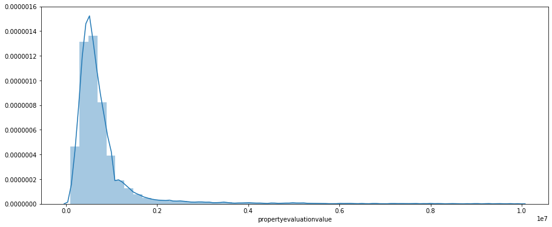

```python
#Checking evaluationvalue distribution
df_above_threshold = df.copy()
import seaborn as sns
plt.figure(figsize = (15,6))
sns.distplot(df.propertyevaluationvalue)
plt.show()
```

Since the dat is sparse setting the limit of threshold to be 1250000

```python
df = df[df.propertyevaluationvalue<=1250000]
df.reset_index(drop = True, inplace = True)
```

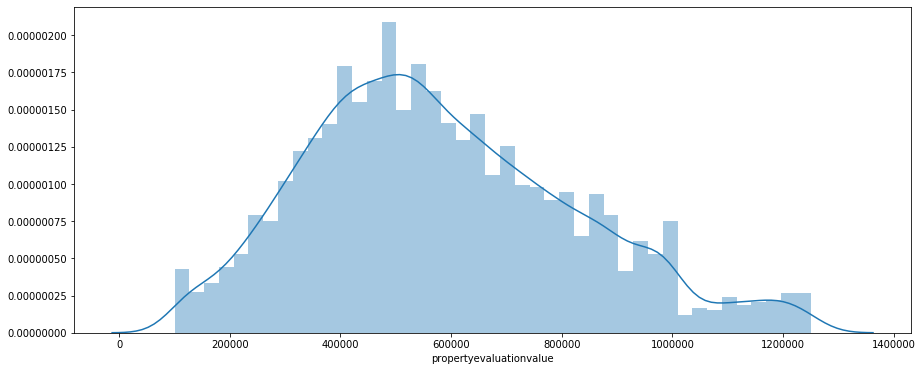

```python
#checking distribution after setting threshold
plt.figure(figsize = (15,6))
sns.distplot(df.propertyevaluationvalue)
plt.show()
```

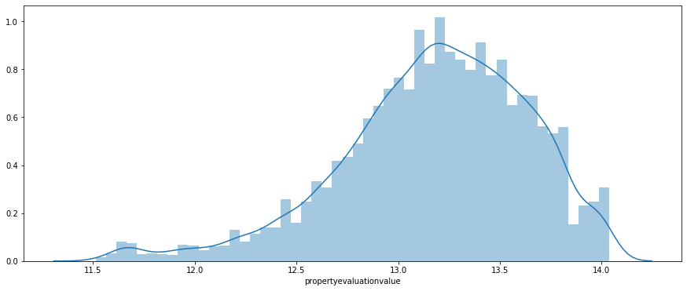

```python
#Cheking for log distribution
plt.figure(figsize = (15,6))
sns.distplot(np.log(df.propertyevaluationvalue))
plt.show()
```

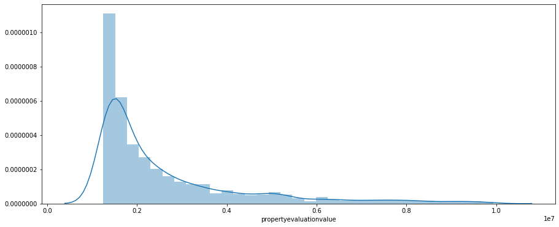

```python
df_above_threshold = df_above_threshold[df_above_threshold.propertyevaluationvalue>1250000]
plt.figure(figsize = (15,6))
sns.distplot(df_above_threshold.propertyevaluationvalue)
plt.show()
```

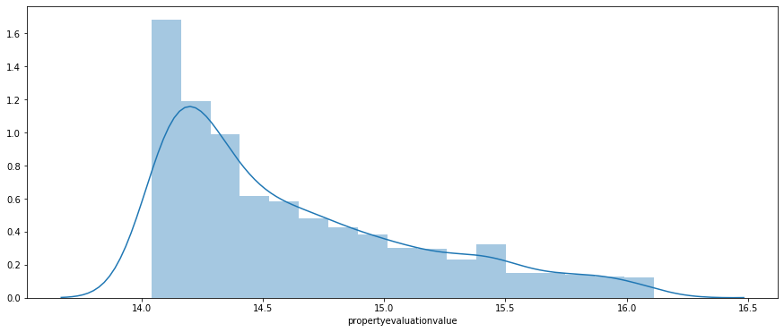

```python
#checking for log distribution
plt.figure(figsize = (15,6))
sns.distplot(np.log(df_above_threshold.propertyevaluationvalue))
plt.show()
```

```python
#checking the shape of the dataset
df.shape
```

```
(14976, 19)
```

```python
#mean and median are almost same hence no outliers in the propery evaluation column
df.propertyevaluationvalue.describe()
```

```
count     14976.00
mean     583533.27
std      242796.24
min      100044.00
25%      405000.00
50%      550000.00
75%      740000.00
max     1250000.00
Name: propertyevaluationvalue, dtype: float64
```

```python
#Checking for unique values in the columns
len(df.propertyid.unique())
```

```
14976
```

Since all the values in the propertyid are unique dropping the column

```python
df.drop('propertyid', axis = 1, inplace = True)
```

## Borough

```python
#checking unique values in borugh
df.borough.unique()
```

```
array([1, 3, 2, 5, 4], dtype=int64)
```

There are only 5 categories. Converting it into categorical type

```python
df.borough = df.borough.astype('category')
```

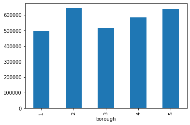

```python
#price variation per borough
df.groupby('borough')['propertyevaluationvalue'].mean().plot(kind = 'bar')
```

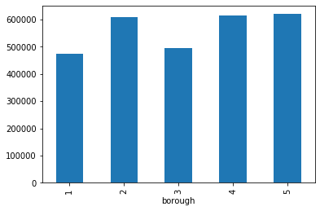

```python
df.groupby('borough')['propertyevaluationvalue'].median().plot(kind = 'bar')
```

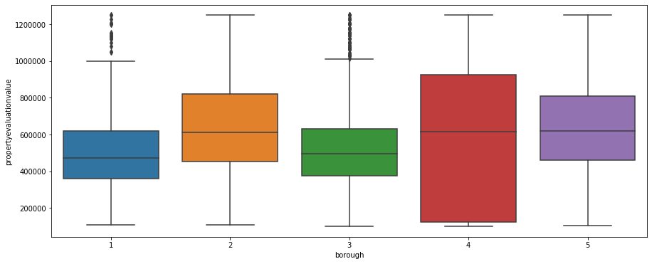

```python
plt.figure(figsize = (15,6))
sns.boxplot(x = df.borough, y = df.propertyevaluationvalue)
plt.show()
```

## State

Since state has only one unique value dropping the column

```python
df.state.unique()
```

```
array(['NY'], dtype=object)
```

```python
df.drop('state', axis =1 , inplace = True)
```

## Surroundings

```python
df.surroundings.value_counts(normalize = True)
```

```
FLUSHING-NORTH     0.05
GREAT KILLS        0.04
BAYSIDE            0.03
CANARSIE           0.02
ELTINGVILLE        0.02
                   ...
BOERUM HILL        0.00
COBBLE HILL-WEST   0.00
FIELDSTON          0.00
FRESH KILLS        0.00
CO-OP CITY         0.00
Name: surroundings, Length: 234, dtype: float64
```

```python
df
```

|  | borough | surroundings | address | zipcode | block | lot | bldgclasscategory | noofresidentialunits | noofcommercialunits | totalnoofunits | landareainsqft | grossareainsqft | yearofconstruction | taxclass_atevaluationtime | bldgclass_atevaluationtime | dateofevaluation | propertyevaluationvalue |
| --- | --- | --- | --- | --- | --- | --- | --- | --- | --- | --- | --- | --- | --- | --- | --- | --- | --- |
| 0 | 1 | BATHGATE | 1473 CROTONA PLACE | 10456 | 2927 | 127 | 02 TWO FAMILY DWELLINGS | 2 | 0 | 2 | 1900 | 2394 | 1990 | 1 | B1 | 2014-05-30 | 540000 |
| 1 | 1 | BATHGATE | 453 EAST 181 | 10457 | 3037 | 110 | 03 THREE FAMILY DWELLINGS | 3 | 0 | 3 | 1687 | 3037 | 2002 | 1 | C0 | 2014-09-13 | 750000 |
| 2 | 1 | BATHGATE | 511 EAST 171 STREET | 10457 | 2912 | 155 | 02 TWO FAMILY DWELLINGS | 2 | 0 | 2 | 2000 | 2400 | 1989 | 1 | B1 | 2014-09-28 | 470000 |
| 3 | 1 | BATHGATE | 547 CLAREMONT PARKWAY | 10457 | 2929 | 134 | 02 TWO FAMILY DWELLINGS | 2 | 0 | 2 | 2356 | 2394 | 1991 | 1 | B1 | 2014-06-05 | 570000 |
| 4 | 1 | BATHGATE | 2063 WASHINGTON AVENUE | 10457 | 3036 | 140 | 02 TWO FAMILY DWELLINGS | 2 | 0 | 2 | 3346 | 2308 | 1993 | 1 | B1 | 2015-02-07 | 640000 |
| ... | ... | ... | ... | ... | ... | ... | ... | ... | ... | ... | ... | ... | ... | ... | ... | ... | ... |
| 14971 | 4 | UPPER EAST SIDE (79-96) | 200 EAST 89TH STREET | 10128 | 1534 | 1102 | 13 CONDOS - ELEVATOR APARTMENTS | 1 | 0 | 1 | 13000 | 773 | 1983 | 2 | R4 | 2014-11-29 | 850000 |
| 14972 | 4 | UPPER EAST SIDE (79-96) | 200 EAST 89TH STREET | 10128 | 1534 | 1162 | 13 CONDOS - ELEVATOR APARTMENTS | 1 | 0 | 1 | 13000 | 562 | 1983 | 2 | R4 | 2014-05-22 | 765000 |
| 14973 | 4 | UPPER EAST SIDE (79-96) | 389 EAST 89TH STREET | 10128 | 1552 | 1320 | 13 CONDOS - ELEVATOR APARTMENTS | 1 | 0 | 1 | 10070 | 624 | 1998 | 2 | R4 | 2014-04-03 | 893718 |
| 14974 | 4 | UPPER EAST SIDE (79-96) | 510 EAST 80TH STREET | 10075 | 1576 | 1048 | 13 CONDOS - ELEVATOR APARTMENTS | 1 | 0 | 1 | 12771 | 593 | 1982 | 2 | R4 | 2014-08-16 | 655000 |
| 14975 | 4 | TRIBECA | 250 SOUTH END AVENUE | 10280 | 16 | 2249 | 13 CONDOS - ELEVATOR APARTMENTS | 1 | 0 | 1 | 12644 | 594 | 1981 | 2 | R4 | 2014-09-17 | 550000 |

14976 rows × 17 columns

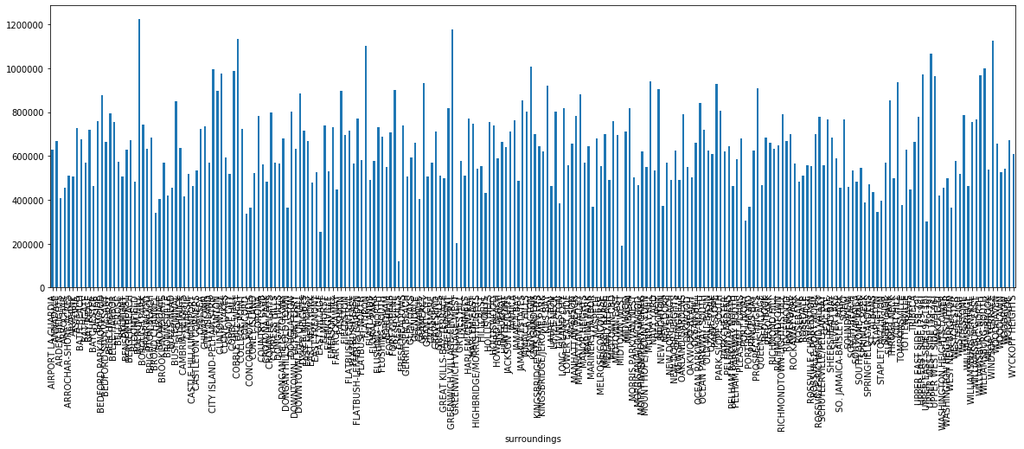

```python
plt.figure()
df.groupby('surroundings')['propertyevaluationvalue'].mean().plot(kind = 'bar',figsize = (20,6))
plt.show()
```

```python
df_surroundings = pd.DataFrame(df.groupby('surroundings')['propertyevaluationvalue'].mean()).sort_values(by = 'propertyevaluationvalue', ascending = False)
df_surroundings.describe()
```

|  | propertyevaluationvalue |
| --- | --- |
| count | 234.00 |
| mean | 634780.11 |
| std | 185389.32 |
| min | 119036.00 |
| 25% | 506068.47 |
| 50% | 625808.73 |
| 75% | 745293.75 |
| max | 1224650.00 |

We see that there is a lot of variation in evaluation price due to the surroundings

```python
df.surroundings = df.surroundings.astype('category')
```

Surroundings have very little data for the model to learn hence dropping the columns

```python
df.drop('surroundings', axis = 1, inplace = True)
```

## Address

It has a lot of unieue values hence dropping the column

```python
df.drop('address', axis = 1, inplace = True)
```

## Zipcode

The area in which the property is located

Zipcode might play an important role in determining the property value. Since it is a high cardinality varible. We can target encode it

```python
zip_code_counts = pd.DataFrame(df.zipcode.value_counts())
```

```python
zip_code_counts[zip_code_counts.zipcode==1].index
```

```
Int64Index([10033, 10028, 10009, 10803, 11430, 10013], dtype='int64')
```

```python
unique_zipcode = []
for i in list(zip_code_counts[zip_code_counts.zipcode==1].index):
    for j in range(len(df)):
        if df['zipcode'][j] == i:
            unique_zipcode.append(j)
```

```python
df.drop(unique_zipcode, axis = 0, inplace = True)
```

```python
df_zipcode = pd.DataFrame(df.groupby('zipcode')['propertyevaluationvalue'].mean()).sort_index(ascending = False)
```

```python
df_zipcode
```

| zipcode | propertyevaluationvalue |
| --- | --- |
| 11694 | 694053.62 |
| 11693 | 550748.00 |
| 11692 | 530899.77 |
| 11691 | 441757.42 |
| 11436 | 482463.16 |
| ... | ... |
| 10012 | 907500.00 |
| 10011 | 703314.29 |
| 10010 | 1151631.14 |
| 10003 | 1071000.00 |
| 10002 | 568290.86 |

160 rows × 1 columns

```python
df_zipcode_median = pd.DataFrame(df.groupby('zipcode')['propertyevaluationvalue'].mean()).sort_index(ascending = False)
```

```python
df_zipcode_median
```

| zipcode | propertyevaluationvalue |
| --- | --- |
| 11694 | 694053.62 |
| 11693 | 550748.00 |
| 11692 | 530899.77 |
| 11691 | 441757.42 |
| 11436 | 482463.16 |
| ... | ... |
| 10012 | 907500.00 |
| 10011 | 703314.29 |
| 10010 | 1151631.14 |
| 10003 | 1071000.00 |
| 10002 | 568290.86 |

160 rows × 1 columns

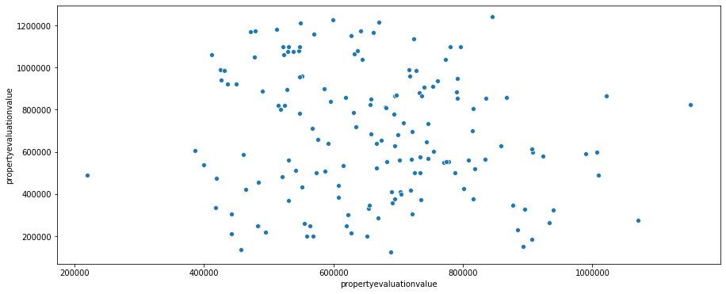

```python
plt.figure(figsize = (15,6))
sns.scatterplot(df_zipcode.propertyevaluationvalue, df.propertyevaluationvalue)
plt.show()
```

```python
df_zipcode_combined = df_zipcode.copy()
df_zipcode_combined['Median'] = df_zipcode_median.propertyevaluationvalue
```

```python
zip_dict = df_zipcode.to_dict()
zip_dict = zip_dict['propertyevaluationvalue']
other_mean = np.array(list(zip_dict.values())).mean()
zip_dict['Other'] = other_mean
```

```python
df.zipcode = df.zipcode.apply(lambda x: zip_dict[x])
```

## Block

The block number to which the property belongs to

```python
block_count = pd.DataFrame(df.block.value_counts(normalize = True))
```

```python
block_count[block_count.block >0.1]
```

|  | block |
| --- | --- |

No value is above 10% hence dropping the columns

```python
df_block = pd.DataFrame(df.groupby('block')['propertyevaluationvalue'].mean()).sort_index()
```

```python
df_block_median = pd.DataFrame(df.groupby('block')['propertyevaluationvalue'].median()).sort_index()
```

```python
df_block_median
```

| block | propertyevaluationvalue |
| --- | --- |
| 14 | 720000.00 |
| 16 | 541250.00 |
| 17 | 110000.00 |
| 25 | 344760.00 |
| 30 | 565000.00 |
| ... | ... |
| 16295 | 842500.00 |
| 16297 | 875000.00 |
| 16306 | 1125000.00 |
| 16309 | 1250000.00 |
| 16314 | 535000.00 |

5956 rows × 1 columns

```python
df_block['median_evaluation'] = df_block_median.propertyevaluationvalue
```

```python
df_block[df_block.propertyevaluationvalue != df_block.median_evaluation]
```

| block | propertyevaluationvalue | median_evaluation |
| --- | --- | --- |
| 16 | 662083.33 | 541250.00 |
| 52 | 789644.67 | 802254.00 |
| 58 | 548271.50 | 413293.00 |
| 59 | 425202.60 | 423000.00 |
| 62 | 919666.67 | 854000.00 |
| ... | ... | ... |
| 16035 | 427679.00 | 352275.00 |
| 16058 | 346500.00 | 290000.00 |
| 16092 | 840566.25 | 858265.00 |
| 16157 | 542750.00 | 576000.00 |
| 16237 | 573750.00 | 625000.00 |

1861 rows × 2 columns

```python
df.drop('block', axis = 1, inplace = True)
```

```python
df.head()
```

|  | borough | zipcode | lot | bldgclasscategory | noofresidentialunits | noofcommercialunits | totalnoofunits | landareainsqft | grossareainsqft | yearofconstruction | taxclass_atevaluationtime | bldgclass_atevaluationtime | dateofevaluation | propertyevaluationvalue |
| --- | --- | --- | --- | --- | --- | --- | --- | --- | --- | --- | --- | --- | --- | --- |
| 0 | 1 | 426892.00 | 127 | 02 TWO FAMILY DWELLINGS | 2 | 0 | 2 | 1900 | 2394 | 1990 | 1 | B1 | 2014-05-30 | 540000 |
| 1 | 1 | 548941.82 | 110 | 03 THREE FAMILY DWELLINGS | 3 | 0 | 3 | 1687 | 3037 | 2002 | 1 | C0 | 2014-09-13 | 750000 |
| 2 | 1 | 548941.82 | 155 | 02 TWO FAMILY DWELLINGS | 2 | 0 | 2 | 2000 | 2400 | 1989 | 1 | B1 | 2014-09-28 | 470000 |
| 3 | 1 | 548941.82 | 134 | 02 TWO FAMILY DWELLINGS | 2 | 0 | 2 | 2356 | 2394 | 1991 | 1 | B1 | 2014-06-05 | 570000 |
| 4 | 1 | 548941.82 | 140 | 02 TWO FAMILY DWELLINGS | 2 | 0 | 2 | 3346 | 2308 | 1993 | 1 | B1 | 2015-02-07 | 640000 |

## Lot

```python
lot_count = pd.DataFrame(df.lot.value_counts(normalize = True))
lot_count
```

|  | lot |
| --- | --- |
| 37 | 0.02 |
| 1 | 0.02 |
| 21 | 0.01 |
| 16 | 0.01 |
| 20 | 0.01 |
| ... | ... |
| 549 | 0.00 |
| 533 | 0.00 |
| 525 | 0.00 |
| 3083 | 0.00 |
| 1923 | 0.00 |

1127 rows × 1 columns

```python
df.groupby('lot')['propertyevaluationvalue'].mean()
```

```
lot
1      636761.47
2      582817.62
3      570516.44
4      613534.59
5      585301.19
          ...
5036   235000.00
5055   270000.00
5305   386000.00
5320   332000.00
5323   425000.00
Name: propertyevaluationvalue, Length: 1127, dtype: float64
```

```python
lot_count[lot_count.lot>0.1]
```

|  | lot |
| --- | --- |

No singel value is above 10% hence dropping the columns

```python
df.drop('lot', axis = 1, inplace = True)
```

## noofresidentialunits

Number of residiential units

```python
#checking for distribution of noofresidentialunits
df.noofresidentialunits.value_counts(normalize = True)
```

```
1     0.60
2     0.30
3     0.07
0     0.03
4     0.00
5     0.00
6     0.00
8     0.00
55    0.00
10    0.00
84    0.00
7     0.00
27    0.00
11    0.00
334   0.00
```

[output cut: 24 more lines]

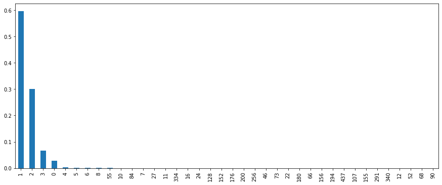

```python
df.noofresidentialunits.value_counts(normalize = True).plot(kind ='bar', figsize = (15,6))
```

```python
df = df[df.noofresidentialunits<=3]
```

```python
df.shape
```

```
(14838, 13)
```

## noofcommercialunits

Nnumber of commertial units in the building

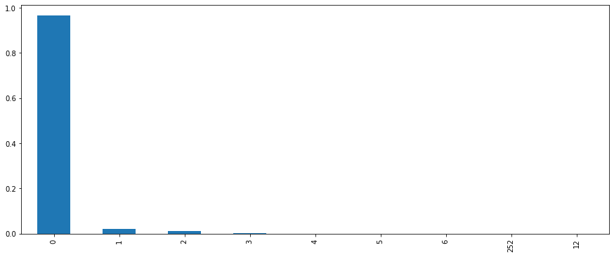

```python
df.noofcommercialunits.value_counts(normalize = True).plot(kind = 'bar', figsize = (15,6))
```

```python
df.drop('noofcommercialunits', axis = 1, inplace = True)
```

## YearofConstrustion

Year in which the property was constructed

```python
today_year = 2019
```

```python
#feature engineering age column
df['age'] = 2019 - df.yearofconstruction
```

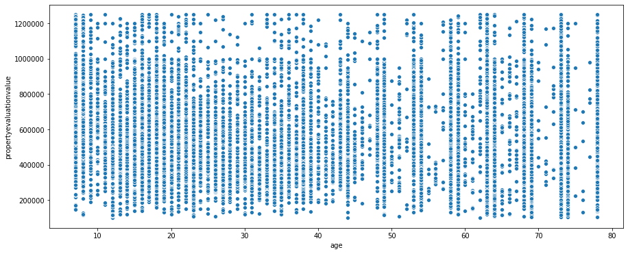

```python
plt.figure(figsize = (15,6))
sns.scatterplot(df.age, df.propertyevaluationvalue)
plt.show()
```

```python
df.drop('yearofconstruction', axis = 1, inplace = True)
```

## Bldgclasscategory and BldgClass_atEvaluation

Bldgclasscategory - Type of home

BldgClass_atEvaluation - Ranking of the prperty according to NYC building class category

```python
#resetting index
df.reset_index(drop=True, inplace = True)
```

```python
#checking the count of each type of building class category
count_cateogry = pd.DataFrame(df.bldgclasscategory.value_counts())
```

```python
#checking unique values
df.bldgclasscategory.unique()
```

```
array(['02 TWO FAMILY DWELLINGS', '03 THREE FAMILY DWELLINGS',
       '03  THREE FAMILY HOMES', '02  TWO FAMILY HOMES',
       '01 ONE FAMILY DWELLINGS', '22  STORE BUILDINGS',
       '22 STORE BUILDINGS', '01  ONE FAMILY HOMES',
       '04 TAX CLASS 1 CONDOS', '13 CONDOS - ELEVATOR APARTMENTS',
       '30 WAREHOUSES', '14  RENTALS - 4-10 UNIT',
       '33  EDUCATIONAL FACILITIES', '15 CONDOS - 2-10 UNIT RESIDENTIAL',
       '05  TAX CLASS 1 VACANT LAND', '30  WAREHOUSES',
       '29  COMMERCIAL GARAGES', '29 COMMERCIAL GARAGES',
       '44 CONDO PARKING', '12 CONDOS - WALKUP APARTMENTS',
       '14 RENTALS - 4-10 UNIT', '21  OFFICE BUILDINGS',
       '37  RELIGIOUS FACILITIES', '27 FACTORIES', '21 OFFICE BUILDINGS',
       '25  LUXURY HOTELS', '38  ASYLUMS AND HOMES',
       '07  RENTALS - WALKUP APARTMENTS', '27  FACTORIES',
       '37 RELIGIOUS FACILITIES', '33 EDUCATIONAL FACILITIES',
       '32 HOSPITAL AND HEALTH FACILITIES', '41 TAX CLASS 4 - OTHER',
       '38 ASYLUMS AND HOMES', '41  TAX CLASS 4 - OTHER',
       '26  OTHER HOTELS', '32  HOSPITAL AND HEALTH FACILITIES',
       '31  COMMERCIAL VACANT LAND', '46 CONDO STORE BUILDINGS',
       '42 CONDO CULTURAL/MEDICAL/EDUCATIONAL/ETC',
       '35  INDOOR PUBLIC AND CULTURAL FACILITIES',
       '16 CONDOS - 2-10 UNIT WITH COMMERCIAL UNIT', '45 CONDO HOTELS'],
      dtype=object)
```

```python
#inpecting data to see any relationship between the below mentioned columns
df.loc[:,['noofresidentialunits','totalnoofunits','bldgclass_atevaluationtime','bldgclasscategory']]
```

|  | noofresidentialunits | totalnoofunits | bldgclass_atevaluationtime | bldgclasscategory |
| --- | --- | --- | --- | --- |
| 0 | 2 | 2 | B1 | 02 TWO FAMILY DWELLINGS |
| 1 | 3 | 3 | C0 | 03 THREE FAMILY DWELLINGS |
| 2 | 2 | 2 | B1 | 02 TWO FAMILY DWELLINGS |
| 3 | 2 | 2 | B1 | 02 TWO FAMILY DWELLINGS |
| 4 | 2 | 2 | B1 | 02 TWO FAMILY DWELLINGS |
| ... | ... | ... | ... | ... |
| 14833 | 1 | 1 | R4 | 13 CONDOS - ELEVATOR APARTMENTS |
| 14834 | 1 | 1 | R4 | 13 CONDOS - ELEVATOR APARTMENTS |
| 14835 | 1 | 1 | R4 | 13 CONDOS - ELEVATOR APARTMENTS |
| 14836 | 1 | 1 | R4 | 13 CONDOS - ELEVATOR APARTMENTS |
| 14837 | 1 | 1 | R4 | 13 CONDOS - ELEVATOR APARTMENTS |

14838 rows × 4 columns

```python
#extrcting features
df['total_houses'] = df.bldgclasscategory.apply(lambda x: int(x[0:2]))
```

```python
df['types_of_house'] = df.bldgclasscategory.apply(lambda x: x[3:])
```

```python
df.drop('bldgclasscategory', axis = 1, inplace = True)
```

```python
df.types_of_house.unique()
```

```
array(['TWO FAMILY DWELLINGS', 'THREE FAMILY DWELLINGS',
       ' THREE FAMILY HOMES', ' TWO FAMILY HOMES', 'ONE FAMILY DWELLINGS',
       ' STORE BUILDINGS', 'STORE BUILDINGS', ' ONE FAMILY HOMES',
       'TAX CLASS 1 CONDOS', 'CONDOS - ELEVATOR APARTMENTS', 'WAREHOUSES',
       ' RENTALS - 4-10 UNIT', ' EDUCATIONAL FACILITIES',
       'CONDOS - 2-10 UNIT RESIDENTIAL', ' TAX CLASS 1 VACANT LAND',
       ' WAREHOUSES', ' COMMERCIAL GARAGES', 'COMMERCIAL GARAGES',
       'CONDO PARKING', 'CONDOS - WALKUP APARTMENTS',
       'RENTALS - 4-10 UNIT', ' OFFICE BUILDINGS',
       ' RELIGIOUS FACILITIES', 'FACTORIES', 'OFFICE BUILDINGS',
       ' LUXURY HOTELS', ' ASYLUMS AND HOMES',
       ' RENTALS - WALKUP APARTMENTS', ' FACTORIES',
       'RELIGIOUS FACILITIES', 'EDUCATIONAL FACILITIES',
       'HOSPITAL AND HEALTH FACILITIES', 'TAX CLASS 4 - OTHER',
       'ASYLUMS AND HOMES', ' TAX CLASS 4 - OTHER', ' OTHER HOTELS',
       ' HOSPITAL AND HEALTH FACILITIES', ' COMMERCIAL VACANT LAND',
       'CONDO STORE BUILDINGS', 'CONDO CULTURAL/MEDICAL/EDUCATIONAL/ETC',
       ' INDOOR PUBLIC AND CULTURAL FACILITIES',
       'CONDOS - 2-10 UNIT WITH COMMERCIAL UNIT', 'CONDO HOTELS'],
      dtype=object)
```

```python
#checking unique
df.bldgclass_atevaluationtime.unique()
```

```
array(['B1', 'C0', 'A5', 'B2', 'K1', 'A2', 'A1', 'A9', 'B9', 'R3', 'B3',
       'A0', 'S1', 'A3', 'R4', 'E2', 'K5', 'S9', 'W8', 'A6', 'R1', 'V0',
       'A4', 'E1', 'K9', 'K4', 'S2', 'G9', 'G2', 'RG', 'R2', 'E4', 'S3',
       'O5', 'O1', 'G5', 'G4', 'M1', 'F5', 'O9', 'O7', 'A7', 'H2', 'O6',
       'N2', 'C3', 'F1', 'E9', 'E3', 'F9', 'GW', 'G8', 'O2', 'W9', 'G1',
       'K7', 'I9', 'F4', 'Z9', 'K2', 'H4', 'I6', 'I5', 'V1', 'RK', 'R6',
       'F2', 'O8', 'RA', 'P8', 'R8', 'RH'], dtype=object)
```

```python
#checking the count of each class
class_count = pd.DataFrame(df.bldgclass_atevaluationtime.value_counts(normalize = True))
```

```python
class_count
```

|  | bldgclass_atevaluationtime |
| --- | --- |
| A5 | 0.23 |
| A2 | 0.12 |
| B2 | 0.12 |
| B1 | 0.11 |
| R4 | 0.07 |
| ... | ... |
| RH | 0.00 |
| R8 | 0.00 |
| E4 | 0.00 |
| O5 | 0.00 |
| G8 | 0.00 |

72 rows × 1 columns

```python
#resetting the index
df.reset_index(drop=True, inplace = True)
```

```python
temp = df.bldgclass_atevaluationtime.apply(lambda x: x[0])
```

```python
df['temp'] = temp
```

```python
pd.DataFrame(df.groupby('temp')['propertyevaluationvalue'].mean()).sort_values(by = 'propertyevaluationvalue',ascending = False)
```

| temp | propertyevaluationvalue |
| --- | --- |
| S | 779135.07 |
| P | 765000.00 |
| M | 748333.33 |
| O | 740826.79 |
| F | 710515.38 |
| K | 702642.74 |
| I | 695538.33 |
| C | 690164.63 |
| E | 678999.14 |
| G | 648177.61 |
| R | 628845.71 |
| W | 622555.00 |
| B | 620114.04 |
| Z | 617000.00 |
| V | 593720.86 |
| A | 535628.32 |
| N | 354938.00 |
| H | 134327.55 |

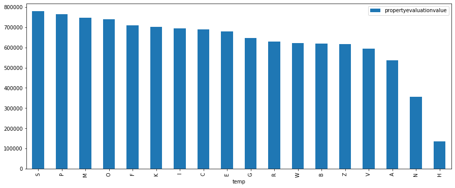

```python
pd.DataFrame(df.groupby('temp')['propertyevaluationvalue'].mean()).sort_values(by = 'propertyevaluationvalue',ascending = False).plot(kind = 'bar', figsize = (15,6))
```

```python
#Grouping ratings
type_of_house = {'I':'Hospitals And Health','P':' Places Of Public Assembly (Indoor) And Cultural',
                'E':'Warehouses','O':'Office Buildings','F':' Factory And Industrial Buildings',
                'K':'Store Buildings', 'S':'Residence - Multiple Use','M':'Pilgrimage','G':'Garages And Gasoline Stations',
                'C':'Walk Up Apartments', 'R':'Condominiums', 'Z':'Miscellaneous', 'W':'Educational Structures',
                'B':'Two Family Dwellings', 'D':'Elevator Apartments', 'V':'Vacant Land', 'A':'One Family Dwellings',
                'N':'Asylums And Homes', 'H':'Hotels'}
```

```python
df['types_of_house'] = df.temp.apply(lambda x: type_of_house[x])
```

```python
df.head()
```

|  | borough | zipcode | noofresidentialunits | totalnoofunits | landareainsqft | grossareainsqft | taxclass_atevaluationtime | bldgclass_atevaluationtime | dateofevaluation | propertyevaluationvalue | age | total_houses | types_of_house | temp |
| --- | --- | --- | --- | --- | --- | --- | --- | --- | --- | --- | --- | --- | --- | --- |
| 0 | 1 | 426892.00 | 2 | 2 | 1900 | 2394 | 1 | B1 | 2014-05-30 | 540000 | 29 | 2 | Two Family Dwellings | B |
| 1 | 1 | 548941.82 | 3 | 3 | 1687 | 3037 | 1 | C0 | 2014-09-13 | 750000 | 17 | 3 | Walk Up Apartments | C |
| 2 | 1 | 548941.82 | 2 | 2 | 2000 | 2400 | 1 | B1 | 2014-09-28 | 470000 | 30 | 2 | Two Family Dwellings | B |
| 3 | 1 | 548941.82 | 2 | 2 | 2356 | 2394 | 1 | B1 | 2014-06-05 | 570000 | 28 | 2 | Two Family Dwellings | B |
| 4 | 1 | 548941.82 | 2 | 2 | 3346 | 2308 | 1 | B1 | 2015-02-07 | 640000 | 26 | 2 | Two Family Dwellings | B |

## Rating

Property class rating acording to NYC building class category

```python
df.rename(columns={'temp':'rating'}, inplace = True)
```

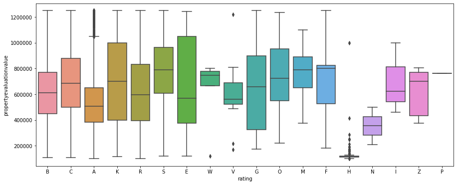

```python
plt.figure(figsize = (15,6))
sns.boxplot(df.rating, df.propertyevaluationvalue)
plt.show()
```

```python
df.head()
```

|  | borough | zipcode | noofresidentialunits | totalnoofunits | landareainsqft | grossareainsqft | taxclass_atevaluationtime | bldgclass_atevaluationtime | dateofevaluation | propertyevaluationvalue | age | total_houses | types_of_house | rating |
| --- | --- | --- | --- | --- | --- | --- | --- | --- | --- | --- | --- | --- | --- | --- |
| 0 | 1 | 426892.00 | 2 | 2 | 1900 | 2394 | 1 | B1 | 2014-05-30 | 540000 | 29 | 2 | Two Family Dwellings | B |
| 1 | 1 | 548941.82 | 3 | 3 | 1687 | 3037 | 1 | C0 | 2014-09-13 | 750000 | 17 | 3 | Walk Up Apartments | C |
| 2 | 1 | 548941.82 | 2 | 2 | 2000 | 2400 | 1 | B1 | 2014-09-28 | 470000 | 30 | 2 | Two Family Dwellings | B |
| 3 | 1 | 548941.82 | 2 | 2 | 2356 | 2394 | 1 | B1 | 2014-06-05 | 570000 | 28 | 2 | Two Family Dwellings | B |
| 4 | 1 | 548941.82 | 2 | 2 | 3346 | 2308 | 1 | B1 | 2015-02-07 | 640000 | 26 | 2 | Two Family Dwellings | B |

```python
df.drop('bldgclass_atevaluationtime', axis = 1, inplace = True)
```

## Data of Evaluation

Last data on which the property was evaluated

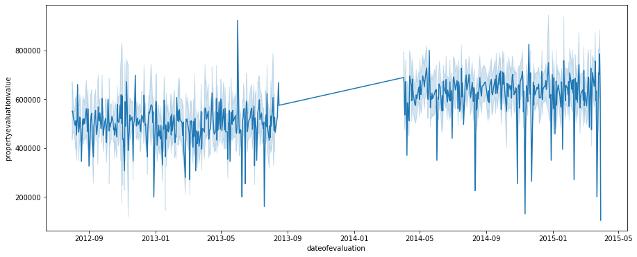

```python
plt.figure(figsize = (15,6))
sns.lineplot(x = df.dateofevaluation, y = df.propertyevaluationvalue)
plt.show()
```

```python
df['years_since_evaluation'] = 2019 - df.dateofevaluation.dt.year
```

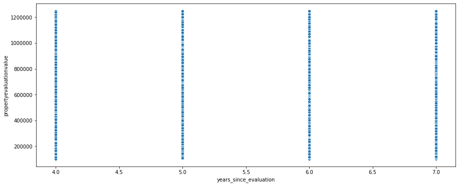

```python
plt.figure(figsize = (15,6))
sns.scatterplot(df.years_since_evaluation, df.propertyevaluationvalue)
plt.show()
```

```python
df.drop('dateofevaluation', axis = 1, inplace = True)
```

## Landareainsqft and Grossareainsqft

### Landareainsqft

Area of the land from border to border

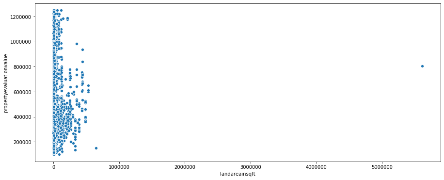

```python
plt.figure(figsize = (15,6))
sns.scatterplot(df.landareainsqft, df.propertyevaluationvalue)
plt.show()
```

```python
#removing outliers
df[df.landareainsqft > 800000].index
```

```
Int64Index([6921], dtype='int64')
```

```python
#dropping the row
df.drop(df[df.landareainsqft > 800000].index, axis = 0, inplace = True)
```

### Grossareainsqft

Livable space in the property (carpet area)

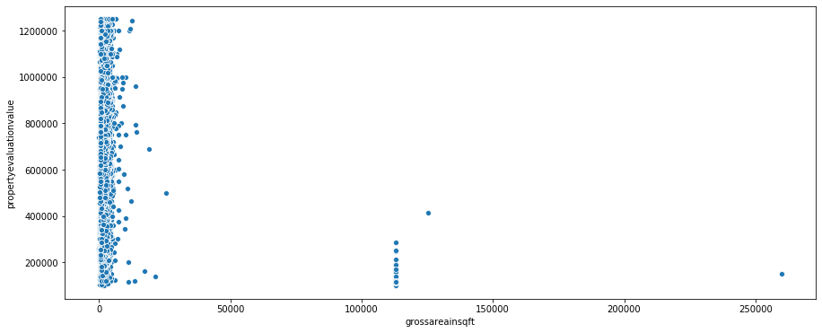

```python
plt.figure(figsize = (15,6))
sns.scatterplot(df.grossareainsqft, df.propertyevaluationvalue)
plt.show()
```

```python
#finding location of outliers
df[df.grossareainsqft>60000].index
```

```
Int64Index([ 3339,  3855, 10248, 10249, 10250, 10251, 10252, 10253, 10254,
            10255,
            ...
            14814, 14815, 14816, 14817, 14818, 14819, 14822, 14823, 14824,
            14825],
           dtype='int64', length=142)
```

```python
#removing outliers
df.drop(df[df.grossareainsqft>60000].index, axis = 0, inplace = True)
```

Doing datatype conversions

```python
df.select_dtypes('object').columns
```

```
Index(['types_of_house', 'rating'], dtype='object')
```

```python
df[df.select_dtypes('object').columns] = df[df.select_dtypes('object').columns].astype('category')
```

```python
df.dtypes
```

```
borough                      category
zipcode                       float64
noofresidentialunits            int64
totalnoofunits                  int64
landareainsqft                  int64
grossareainsqft                 int64
taxclass_atevaluationtime       int64
propertyevaluationvalue         int64
age                             int64
total_houses                    int64
types_of_house               category
rating                       category
years_since_evaluation          int64
dtype: object
```

## Tax Class at Evaluation Time

```python
#converting into category
df.taxclass_atevaluationtime = df.taxclass_atevaluationtime.astype('category')
```

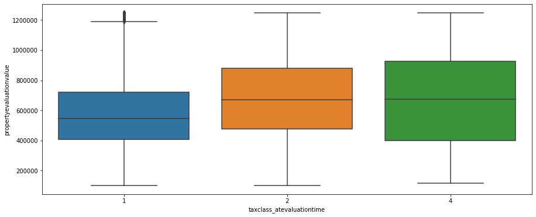

```python
plt.figure(figsize = (15,6))
sns.boxplot(df.taxclass_atevaluationtime, df.propertyevaluationvalue)
plt.show()
```

```python
df1 = df.copy()
```

```python
df.head()
```

|  | borough | zipcode | noofresidentialunits | totalnoofunits | landareainsqft | grossareainsqft | taxclass_atevaluationtime | propertyevaluationvalue | age | total_houses | types_of_house | rating | years_since_evaluation |
| --- | --- | --- | --- | --- | --- | --- | --- | --- | --- | --- | --- | --- | --- |
| 0 | 1 | 426892.00 | 2 | 2 | 1900 | 2394 | 1 | 540000 | 29 | 2 | Two Family Dwellings | B | 5 |
| 1 | 1 | 548941.82 | 3 | 3 | 1687 | 3037 | 1 | 750000 | 17 | 3 | Walk Up Apartments | C | 5 |
| 2 | 1 | 548941.82 | 2 | 2 | 2000 | 2400 | 1 | 470000 | 30 | 2 | Two Family Dwellings | B | 5 |
| 3 | 1 | 548941.82 | 2 | 2 | 2356 | 2394 | 1 | 570000 | 28 | 2 | Two Family Dwellings | B | 5 |
| 4 | 1 | 548941.82 | 2 | 2 | 3346 | 2308 | 1 | 640000 | 26 | 2 | Two Family Dwellings | B | 4 |

```python
df.dtypes
```

```
borough                      category
zipcode                       float64
noofresidentialunits            int64
totalnoofunits                  int64
landareainsqft                  int64
grossareainsqft                 int64
taxclass_atevaluationtime    category
propertyevaluationvalue         int64
age                             int64
total_houses                    int64
types_of_house               category
rating                       category
years_since_evaluation          int64
dtype: object
```

```python
df.drop('types_of_house', axis = 1, inplace = True)
```

```python
x = df.drop('propertyevaluationvalue', axis = 1)
y = df.propertyevaluationvalue
```

```python
from sklearn.model_selection import train_test_split
```

```python
trainx, testx, trainy, testy = train_test_split(x,y, test_size = 0.2, random_state = 123)
```

```python
testx.shape
```

```
(2939, 11)
```

```python
trainx1 = pd.get_dummies(trainx, drop_first = True)
testx1 = pd.get_dummies(testx, drop_first = True)
```

Checking for alignment issues

```python
testx1.columns.difference(trainx1.columns)
```

```
Index([], dtype='object')
```

```python
trainx1.columns.difference(testx1.columns)
```

```
Index([], dtype='object')
```

No alignment issues so going for model building

## Decision Tree

```python
from sklearn.tree import DecisionTreeRegressor
from sklearn.model_selection import GridSearchCV
```

```python
parameters_dtc = {'max_depth':range(1,15), 'min_samples_split':range(10,70,10)}
dtc = GridSearchCV(DecisionTreeRegressor(random_state = 123), param_grid=parameters_dtc, cv = 5, n_jobs=-1, scoring='neg_mean_absolute_error')
dtc.fit(trainx1, trainy)
```

```
GridSearchCV(cv=5, error_score='raise-deprecating',
             estimator=DecisionTreeRegressor(criterion='mse', max_depth=None,
                                             max_features=None,
                                             max_leaf_nodes=None,
                                             min_impurity_decrease=0.0,
                                             min_impurity_split=None,
                                             min_samples_leaf=1,
                                             min_samples_split=2,
                                             min_weight_fraction_leaf=0.0,
                                             presort=False, random_state=123,
                                             splitter='best'),
             iid='warn', n_jobs=-1,
             param_grid={'max_depth': range(1, 15),
                         'min_samples_split': range(10, 70, 10)},
             pre_dispatch='2*n_jobs', refit=True, return_train_score=False,
             scoring='neg_mean_absolute_error', verbose=0)
```

```python
#best parameters
dtc.best_params_
```

```
{'max_depth': 10, 'min_samples_split': 60}
```

```python
dtc.best_estimator_
```

```
DecisionTreeRegressor(criterion='mse', max_depth=10, max_features=None,
                      max_leaf_nodes=None, min_impurity_decrease=0.0,
                      min_impurity_split=None, min_samples_leaf=1,
                      min_samples_split=60, min_weight_fraction_leaf=0.0,
                      presort=False, random_state=123, splitter='best')
```

```python
#defining a regression metric
def regression_metrics(trainx, trainy, testx, testy, model):
    print('---Train---')
    print('MAPE: {}'.format(np.mean(np.abs((trainy - model.predict(trainx)) / trainy)) * 100))
    print('---Test---')
    print('MAPE: {}'.format(np.mean(np.abs((testy - model.predict(testx)) / testy)) * 100))
```

```python
regression_metrics(trainx1, trainy, testx1, testy, dtc.best_estimator_)
```

```
---Train---
MAPE: 22.26488016470713
---Test---
MAPE: 24.090878968129832
```

```python
from mlxtend.plotting import plot_learning_curves
```

```
([105397.72125993347,
  103796.16423068184,
  101699.40665619825,
  99010.58215076021,
  99550.24802133367,
  98530.0043856072,
  98350.97994553653,
  99640.9326587552,
  99833.12711305979,
  99463.59250296268],
 [130673.76728222218,
  120298.27084334774,
  119957.23872860438,
  115451.51390948045,
  114981.44467401486,
  114363.7613118158,
  113343.4957904948,
  111315.94799966953,
  111447.18050433406,
  110487.83136447541])
```

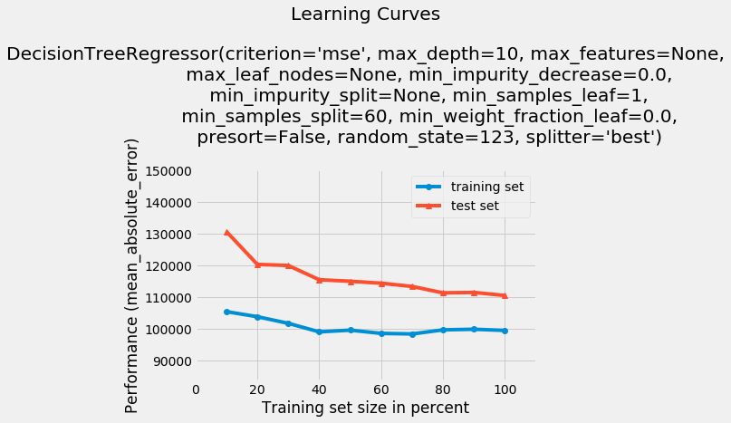

```python
#plotting learning curves
plot_learning_curves(trainx1, trainy, testx1, testy, dtc.best_estimator_, scoring='mean_absolute_error')
```

```python
#grthering inportant features
index_dtc = pd.DataFrame(dtc.best_estimator_.feature_importances_, index = trainx1.columns, columns = ['FI']).sort_values(by='FI', ascending = False).index[:14]
```

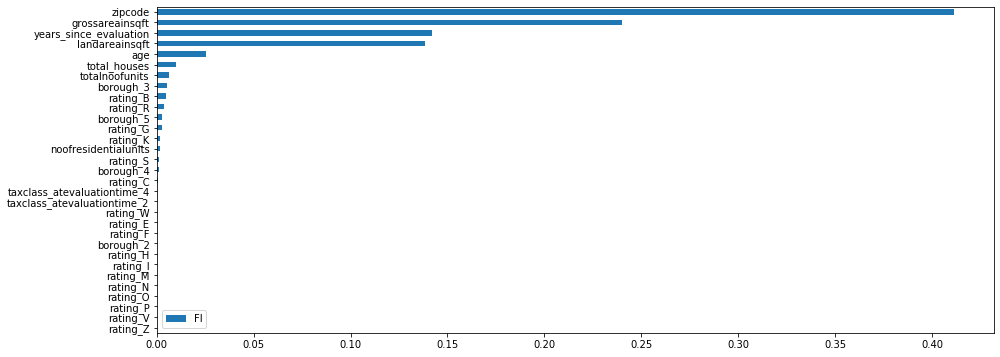

```python
#visual representation of the feature importance
plt.figure()
pd.DataFrame(dtc.best_estimator_.feature_importances_, index = trainx1.columns,
             columns = ['FI']).sort_values(by='FI', ascending = True).plot(kind = 'barh', figsize = (15,6))
plt.show()
```

## After Feature Selection

Feture selection is usually done to reduce noise in the data and to reduce the complexity of the model. Features are eleminated based on their contribution to the model.

```python
#Feature selection
trainx1_dtc = trainx1[index_dtc]
testx1_dtc = testx1[index_dtc]
```

```python
#fitting decision tree
dtc.best_estimator_.fit(trainx1_dtc, trainy)
```

```
DecisionTreeRegressor(criterion='mse', max_depth=10, max_features=None,
                      max_leaf_nodes=None, min_impurity_decrease=0.0,
                      min_impurity_split=None, min_samples_leaf=1,
                      min_samples_split=60, min_weight_fraction_leaf=0.0,
                      presort=False, random_state=123, splitter='best')
```

```python
regression_metrics(trainx1_dtc, trainy, testx1_dtc, testy, dtc.best_estimator_)
```

```
---Train---
MAPE: 22.273513520328837
---Test---
MAPE: 24.220687913880816
```

```
([105397.72125993347,
  103796.16423068184,
  101821.69406999675,
  98949.06556770136,
  99754.93777903252,
  98602.72335490205,
  98425.10268821903,
  99857.41358617246,
  99933.26730047046,
  99547.15665553536],
 [130497.70588095191,
  120388.97893566938,
  119998.78984348163,
  115951.82806864081,
  115164.66025858195,
  114823.46073024794,
  113939.73460664834,
  111201.61027715639,
  111517.01909092108,
  110636.70178900947])
```

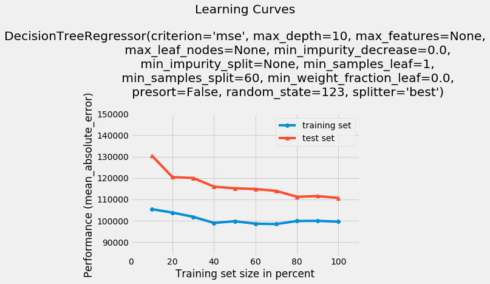

```python
#plotting learnings curves
plot_learning_curves(trainx1_dtc, trainy, testx1_dtc, testy, dtc.best_estimator_, scoring='mean_absolute_error')
```

## Random Forest

```python
from sklearn.ensemble import RandomForestRegressor
```

```python
#using gridsearch to tune parameters
parameters_rfr = {'n_estimators':range(100,200,10),'max_depth': range(1,10)}
rfr = GridSearchCV(RandomForestRegressor(random_state = 123), param_grid=parameters_rfr, cv = 5, n_jobs=-1, scoring = 'neg_mean_absolute_error')
rfr.fit(trainx1,trainy)
```

```
GridSearchCV(cv=5, error_score='raise-deprecating',
             estimator=RandomForestRegressor(bootstrap=True, criterion='mse',
                                             max_depth=None,
                                             max_features='auto',
                                             max_leaf_nodes=None,
                                             min_impurity_decrease=0.0,
                                             min_impurity_split=None,
                                             min_samples_leaf=1,
                                             min_samples_split=2,
                                             min_weight_fraction_leaf=0.0,
                                             n_estimators='warn', n_jobs=None,
                                             oob_score=False, random_state=123,
                                             verbose=0, warm_start=False),
             iid='warn', n_jobs=-1,
             param_grid={'max_depth': range(1, 10),
                         'n_estimators': range(100, 200, 10)},
             pre_dispatch='2*n_jobs', refit=True, return_train_score=False,
             scoring='neg_mean_absolute_error', verbose=0)
```

```python
#best parameters
rfr.best_params_
```

```
{'max_depth': 9, 'n_estimators': 100}
```

```python
regression_metrics(trainx1, trainy, testx1, testy, rfr.best_estimator_)
```

```
---Train---
MAPE: 20.694930263973728
---Test---
MAPE: 22.863924006657246
```

```python
#getting important features
index = list(pd.DataFrame(rfr.best_estimator_.feature_importances_, index = trainx1.columns, columns = ['FI']).sort_values(by='FI', ascending = False)[:12].index)
```

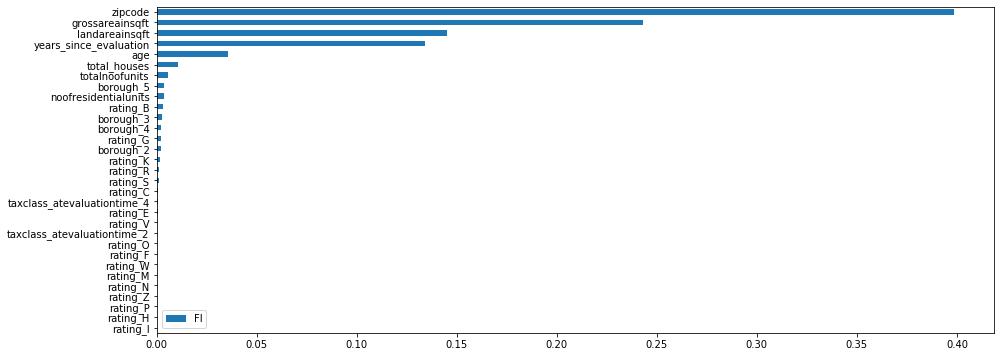

```python
#Visual representation of feature importance
plt.figure()
pd.DataFrame(rfr.best_estimator_.feature_importances_, index = trainx1.columns, columns = ['FI']).sort_values(by='FI', ascending = True).plot(kind = 'barh', figsize = (15,6))
plt.show()
```

```
([64529.208867506284,
  73586.20791376311,
  79679.29172232588,
  81375.6921297536,
  84511.43529119962,
  86433.3187312867,
  88693.20299923587,
  89974.56799831708,
  90811.85187409828,
  91149.12562316377],
 [113093.83925322008,
  109280.17307873162,
  107892.54903706946,
  106602.96372150745,
  105157.3612366159,
  103920.32054072684,
  103801.82389156848,
  102952.9527357368,
  102565.82464244154,
  102063.1859878751])
```

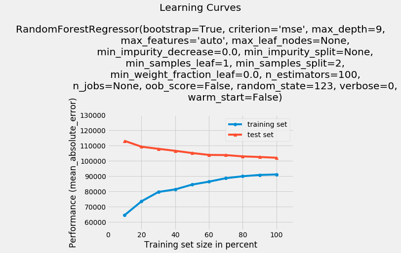

```python
#plot learning curves
plot_learning_curves(trainx1, trainy, testx1, testy, rfr.best_estimator_, scoring='mean_absolute_error')
```

#### After Feature Elimination

```python
#selecting features
trainx1_rfr = trainx1[index]
testx1_rfr = testx1[index]
```

```python
rfr.best_estimator_.fit(trainx1_rfr, trainy)
```

```
RandomForestRegressor(bootstrap=True, criterion='mse', max_depth=9,
                      max_features='auto', max_leaf_nodes=None,
                      min_impurity_decrease=0.0, min_impurity_split=None,
                      min_samples_leaf=1, min_samples_split=2,
                      min_weight_fraction_leaf=0.0, n_estimators=100,
                      n_jobs=None, oob_score=False, random_state=123, verbose=0,
                      warm_start=False)
```

```python
regression_metrics(trainx1_rfr, trainy, testx1_rfr, testy, rfr.best_estimator_)
```

```
---Train---
MAPE: 20.65325366502092
---Test---
MAPE: 22.905913539808314
```

```
([64457.096876753734,
  73592.28320827094,
  79487.64971170238,
  81339.71100297198,
  84457.24567174441,
  86344.51365740658,
  88616.38383657677,
  89810.14196435722,
  90662.85246073663,
  91009.99718524147],
 [113103.41732588605,
  109389.96770412571,
  108213.71567094696,
  106724.1342561133,
  105301.50767965785,
  104030.70041421584,
  103881.82779006835,
  102884.42410170755,
  102789.53482894461,
  102295.36898647457])
```

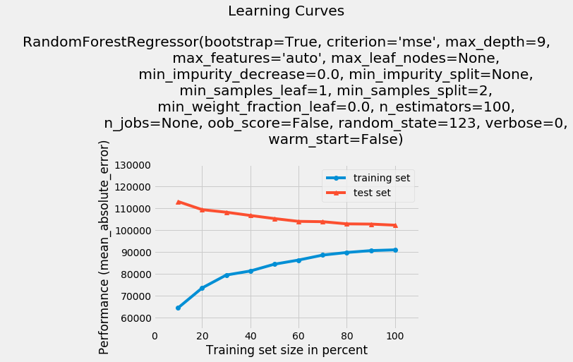

```python
plot_learning_curves(trainx1_rfr, trainy, testx1_rfr, testy, rfr.best_estimator_, scoring='mean_absolute_error')
```

Building simple models

## Linear Regression

```python
from sklearn.linear_model import LinearRegression, Lasso, Ridge
```

```python
lr = LinearRegression()
lr.fit(trainx1, trainy)
```

```
LinearRegression(copy_X=True, fit_intercept=True, n_jobs=None, normalize=False)
```

```python
regression_metrics(trainx1, trainy, testx1, testy, lr)
```

```
---Train---
MAPE: 29.840043130978465
---Test---
MAPE: 28.78332446631368
```

## Lasso

```python
ls = Lasso()
ls.fit(trainx1, trainy)
```

```
Lasso(alpha=1.0, copy_X=True, fit_intercept=True, max_iter=1000,
      normalize=False, positive=False, precompute=False, random_state=None,
      selection='cyclic', tol=0.0001, warm_start=False)
```

```python
regression_metrics(trainx1, trainy, testx1, testy, ls)
```

```
---Train---
MAPE: 29.845699121425877
---Test---
MAPE: 28.790150600226177
```

```python
rd = Lasso()
rd.fit(trainx1, trainy)
```

```
Lasso(alpha=1.0, copy_X=True, fit_intercept=True, max_iter=1000,
      normalize=False, positive=False, precompute=False, random_state=None,
      selection='cyclic', tol=0.0001, warm_start=False)
```

```python
regression_metrics(trainx1, trainy, testx1, testy, rd)
```

```
---Train---
MAPE: 29.845699121425877
---Test---
MAPE: 28.790150600226177
```

## Elastic Net

```python
from sklearn.linear_model import ElasticNet
```

```python
parameters_elastic = {'l1_ratio':np.arange(0,1,0.1)}
elastic = GridSearchCV(ElasticNet(), param_grid=parameters_elastic, cv = 5, n_jobs=-1)
elastic.fit(trainx1, trainy)
```

```
GridSearchCV(cv=5, error_score='raise-deprecating',
             estimator=ElasticNet(alpha=1.0, copy_X=True, fit_intercept=True,
                                  l1_ratio=0.5, max_iter=1000, normalize=False,
                                  positive=False, precompute=False,
                                  random_state=None, selection='cyclic',
                                  tol=0.0001, warm_start=False),
             iid='warn', n_jobs=-1,
             param_grid={'l1_ratio': array([0. , 0.1, 0.2, 0.3, 0.4, 0.5, 0.6, 0.7, 0.8, 0.9])},
             pre_dispatch='2*n_jobs', refit=True, return_train_score=False,
             scoring=None, verbose=0)
```

```python
elastic.best_params_
```

```
{'l1_ratio': 0.9}
```

```python
elastic.best_estimator_
```

```
ElasticNet(alpha=1.0, copy_X=True, fit_intercept=True, l1_ratio=0.9,
           max_iter=1000, normalize=False, positive=False, precompute=False,
           random_state=None, selection='cyclic', tol=0.0001, warm_start=False)
```

```python
regression_metrics(trainx1, trainy, testx1, testy, elastic.best_estimator_)
```

```
---Train---
MAPE: 30.42063423094185
---Test---
MAPE: 29.261029256616368
```

## Voting

```python
from sklearn.ensemble import VotingRegressor
```

```python
voting = VotingRegressor([('rfr',rfr.best_estimator_), ('dtc', dtc.best_estimator_)],n_jobs=-1)
voting.fit(trainx1, trainy)
```

```
VotingRegressor(estimators=[('rfr',
                             RandomForestRegressor(bootstrap=True,
                                                   criterion='mse', max_depth=9,
                                                   max_features='auto',
                                                   max_leaf_nodes=None,
                                                   min_impurity_decrease=0.0,
                                                   min_impurity_split=None,
                                                   min_samples_leaf=1,
                                                   min_samples_split=2,
                                                   min_weight_fraction_leaf=0.0,
                                                   n_estimators=100,
                                                   n_jobs=None, oob_score=False,
                                                   random_state=123, verbose=0,
                                                   warm_start=False)),
                            ('dtc',
                             DecisionTreeRegressor(criterion='mse',
                                                   max_depth=10,
                                                   max_features=None,
                                                   max_leaf_nodes=None,
                                                   min_impurity_decrease=0.0,
                                                   min_impurity_split=None,
                                                   min_samples_leaf=1,
                                                   min_samples_split=60,
                                                   min_weight_fraction_leaf=0.0,
                                                   presort=False,
                                                   random_state=123,
                                                   splitter='best'))],
                n_jobs=-1, weights=None)
```

```python
regression_metrics(trainx1, trainy, testx1, testy, voting)
```

```
---Train---
MAPE: 21.198584742531363
---Test---
MAPE: 23.189881623499208
```

```python
from xgboost.sklearn import XGBRegressor
```

```python
gcb = XGBRegressor(max_depth = 12, objective='reg:squarederror')
gcb.fit(trainx1, trainy)
```

```
XGBRegressor(base_score=0.5, booster='gbtree', colsample_bylevel=1,
             colsample_bynode=1, colsample_bytree=1, gamma=0,
             importance_type='gain', learning_rate=0.1, max_delta_step=0,
             max_depth=12, min_child_weight=1, missing=None, n_estimators=100,
             n_jobs=1, nthread=None, objective='reg:squarederror',
             random_state=0, reg_alpha=0, reg_lambda=1, scale_pos_weight=1,
             seed=None, silent=None, subsample=1, verbosity=1)
```

```python
regression_metrics(trainx1, trainy, testx1, testy, elastic.best_estimator_)
```

```
---Train---
MAPE: 30.42063423094185
---Test---
MAPE: 29.261029256616368
```

```python
df
```

|  | borough | zipcode | noofresidentialunits | totalnoofunits | landareainsqft | grossareainsqft | taxclass_atevaluationtime | propertyevaluationvalue | age | total_houses | rating | years_since_evaluation |
| --- | --- | --- | --- | --- | --- | --- | --- | --- | --- | --- | --- | --- |
| 0 | 1 | 426892.00 | 2 | 2 | 1900 | 2394 | 1 | 540000 | 29 | 2 | B | 5 |
| 1 | 1 | 548941.82 | 3 | 3 | 1687 | 3037 | 1 | 750000 | 17 | 3 | C | 5 |
| 2 | 1 | 548941.82 | 2 | 2 | 2000 | 2400 | 1 | 470000 | 30 | 2 | B | 5 |
| 3 | 1 | 548941.82 | 2 | 2 | 2356 | 2394 | 1 | 570000 | 28 | 2 | B | 5 |
| 4 | 1 | 548941.82 | 2 | 2 | 3346 | 2308 | 1 | 640000 | 26 | 2 | B | 4 |
| ... | ... | ... | ... | ... | ... | ... | ... | ... | ... | ... | ... | ... |
| 14833 | 4 | 989682.62 | 1 | 1 | 13000 | 773 | 2 | 850000 | 36 | 13 | R | 5 |
| 14834 | 4 | 989682.62 | 1 | 1 | 13000 | 562 | 2 | 765000 | 36 | 13 | R | 5 |
| 14835 | 4 | 989682.62 | 1 | 1 | 10070 | 624 | 2 | 893718 | 21 | 13 | R | 5 |
| 14836 | 4 | 733500.00 | 1 | 1 | 12771 | 593 | 2 | 655000 | 37 | 13 | R | 5 |
| 14837 | 4 | 662083.33 | 1 | 1 | 12644 | 594 | 2 | 550000 | 38 | 13 | R | 5 |

14695 rows × 12 columns

## Test

Preprocessing test dataset

```python
test = pd.read_excel('Test.xlsx')
```

```python
test.columns = [x.lower().replace(' ', '_') for x in test.columns]
```

```python
test.zipcode = test.zipcode.apply(lambda x: x if x in zip_dict.keys() else 'Other')
```

```python
#target encoding zipcode
test.zipcode = test.zipcode.apply(lambda x: zip_dict[x])
```

```python
test.head()
```

|  | propertyid | borough | state | surroundings | address | zipcode | block | lot | bldgclasscategory | noofresidentialunits | noofcommercialunits | totalnoofunits | landareainsqft | grossareainsqft | yearofconstruction | taxclass_atevaluationtime | bldgclass_atevaluationtime | dateofevaluation |
| --- | --- | --- | --- | --- | --- | --- | --- | --- | --- | --- | --- | --- | --- | --- | --- | --- | --- | --- |
| 0 | PR51101 | 1 | NY | BATHGATE | 3860 3 AVENUE | 548941.82 | 2929 | 117 | 02 TWO FAMILY HOMES | 2 | 0 | 2 | 2498 | 2394 | 1995 | 1 | B1 | 2013-06-24 |
| 1 | PR51102 | 1 | NY | BATHGATE | 455 E. 179TH STREET | 548941.82 | 3036 | 65 | 02 TWO FAMILY DWELLINGS | 2 | 0 | 2 | 2033 | 2340 | 1994 | 1 | B1 | 2014-08-28 |
| 2 | PR51103 | 1 | NY | BATHGATE | 4415 3 AVENUE | 548941.82 | 3048 | 51 | 14 RENTALS - 4-10 UNIT | 4 | 1 | 5 | 2500 | 6000 | 1963 | 2 | S4 | 2015-01-31 |
| 3 | PR51104 | 1 | NY | BATHGATE | 407 EAST 174 STREET | 548941.82 | 2899 | 34 | 30 WAREHOUSES | 0 | 1 | 1 | 3439 | 3320 | 1951 | 4 | E1 | 2015-03-12 |
| 4 | PR51105 | 1 | NY | EAST TREMONT | 2175 CROTONA AVENUE | 548941.82 | 3083 | 40 | 03 THREE FAMILY DWELLINGS | 3 | 0 | 3 | 1348 | 2931 | 1997 | 1 | C0 | 2014-06-07 |

```python
#applying the same feature engineering techniques that were applied on train
test['total_houses'] = test.bldgclasscategory.apply(lambda x: int(x[0:2]))
test['rating'] = test.bldgclass_atevaluationtime.apply(lambda x: x[0])
test['age'] = 2019 - test.yearofconstruction
test['years_since_evaluation'] = 2019 - test.dateofevaluation.dt.year
```

```python
test
```

|  | propertyid | borough | state | surroundings | address | zipcode | block | lot | bldgclasscategory | noofresidentialunits | ... | landareainsqft | grossareainsqft | yearofconstruction | taxclass_atevaluationtime | bldgclass_atevaluationtime | dateofevaluation | total_houses | rating | age | years_since_evaluation |
| --- | --- | --- | --- | --- | --- | --- | --- | --- | --- | --- | --- | --- | --- | --- | --- | --- | --- | --- | --- | --- | --- |
| 0 | PR51101 | 1 | NY | BATHGATE | 3860 3 AVENUE | 548941.82 | 2929 | 117 | 02 TWO FAMILY HOMES | 2 | ... | 2498 | 2394 | 1995 | 1 | B1 | 2013-06-24 | 2 | B | 24 | 6 |
| 1 | PR51102 | 1 | NY | BATHGATE | 455 E. 179TH STREET | 548941.82 | 3036 | 65 | 02 TWO FAMILY DWELLINGS | 2 | ... | 2033 | 2340 | 1994 | 1 | B1 | 2014-08-28 | 2 | B | 25 | 5 |
| 2 | PR51103 | 1 | NY | BATHGATE | 4415 3 AVENUE | 548941.82 | 3048 | 51 | 14 RENTALS - 4-10 UNIT | 4 | ... | 2500 | 6000 | 1963 | 2 | S4 | 2015-01-31 | 14 | S | 56 | 4 |
| 3 | PR51104 | 1 | NY | BATHGATE | 407 EAST 174 STREET | 548941.82 | 2899 | 34 | 30 WAREHOUSES | 0 | ... | 3439 | 3320 | 1951 | 4 | E1 | 2015-03-12 | 30 | E | 68 | 4 |
| 4 | PR51105 | 1 | NY | EAST TREMONT | 2175 CROTONA AVENUE | 548941.82 | 3083 | 40 | 03 THREE FAMILY DWELLINGS | 3 | ... | 1348 | 2931 | 1997 | 1 | C0 | 2014-06-07 | 3 | C | 22 | 5 |
| ... | ... | ... | ... | ... | ... | ... | ... | ... | ... | ... | ... | ... | ... | ... | ... | ... | ... | ... | ... | ... | ... |
| 2931 | PR54032 | 4 | NY | UPPER EAST SIDE (79-96) | 200 EAST 89TH STREET, 16F | 989682.62 | 1534 | 1207 | 13 CONDOS - ELEVATOR APARTMENTS | 1 | ... | 13000 | 638 | 1983 | 2 | R4 | 2015-02-21 | 13 | R | 36 | 4 |
| 2932 | PR54033 | 4 | NY | UPPER EAST SIDE (79-96) | 360 EAST 89TH STREET | 989682.62 | 1551 | 1165 | 13 CONDOS - ELEVATOR APARTMENTS | 1 | ... | 7755 | 2049 | 2011 | 2 | R4 | 2014-06-04 | 13 | R | 8 | 5 |
| 2933 | PR54034 | 4 | NY | CIVIC CENTER | 30 PARK PLACE | 659554.54 | 123 | 1176 | 13 CONDOS - ELEVATOR APARTMENTS | 1 | ... | 29715 | 1538 | 2004 | 2 | R4 | 2014-08-06 | 13 | R | 15 | 5 |
| 2934 | PR54035 | 4 | NY | CIVIC CENTER | 77 READE STREET | 659554.54 | 149 | 1013 | 13 CONDOS - ELEVATOR APARTMENTS | 1 | ... | 11670 | 1497 | 2005 | 2 | R4 | 2014-04-30 | 13 | R | 14 | 5 |
| 2935 | PR54036 | 4 | NY | HARLEM-UPPER | 608 WEST 149 STREET | 659554.54 | 2095 | 1001 | 42 CONDO CULTURAL/MEDICAL/EDUCATIONAL/ETC | 0 | ... | 9992 | 10411 | 2001 | 4 | RA | 2014-10-25 | 42 | R | 18 | 5 |

2936 rows × 22 columns

```python
drop_cols = ['state', 'surroundings', 'address', 'block', 'lot','dateofevaluation','bldgclass_atevaluationtime'
             ,'bldgclasscategory', 'dateofevaluation', 'yearofconstruction', 'noofcommercialunits']
test.drop(drop_cols, axis = 1, inplace = True)
```

```python
test
```

|  | propertyid | borough | zipcode | noofresidentialunits | totalnoofunits | landareainsqft | grossareainsqft | taxclass_atevaluationtime | total_houses | rating | age | years_since_evaluation |
| --- | --- | --- | --- | --- | --- | --- | --- | --- | --- | --- | --- | --- |
| 0 | PR51101 | 1 | 548941.82 | 2 | 2 | 2498 | 2394 | 1 | 2 | B | 24 | 6 |
| 1 | PR51102 | 1 | 548941.82 | 2 | 2 | 2033 | 2340 | 1 | 2 | B | 25 | 5 |
| 2 | PR51103 | 1 | 548941.82 | 4 | 5 | 2500 | 6000 | 2 | 14 | S | 56 | 4 |
| 3 | PR51104 | 1 | 548941.82 | 0 | 1 | 3439 | 3320 | 4 | 30 | E | 68 | 4 |
| 4 | PR51105 | 1 | 548941.82 | 3 | 3 | 1348 | 2931 | 1 | 3 | C | 22 | 5 |
| ... | ... | ... | ... | ... | ... | ... | ... | ... | ... | ... | ... | ... |
| 2931 | PR54032 | 4 | 989682.62 | 1 | 1 | 13000 | 638 | 2 | 13 | R | 36 | 4 |
| 2932 | PR54033 | 4 | 989682.62 | 1 | 1 | 7755 | 2049 | 2 | 13 | R | 8 | 5 |
| 2933 | PR54034 | 4 | 659554.54 | 1 | 1 | 29715 | 1538 | 2 | 13 | R | 15 | 5 |
| 2934 | PR54035 | 4 | 659554.54 | 1 | 1 | 11670 | 1497 | 2 | 13 | R | 14 | 5 |
| 2935 | PR54036 | 4 | 659554.54 | 0 | 1 | 9992 | 10411 | 4 | 42 | R | 18 | 5 |

2936 rows × 12 columns

```python
df.columns.difference(test.columns)
```

```
Index(['propertyevaluationvalue'], dtype='object')
```

```python
test.columns.difference(df.columns)
```

```
Index(['propertyid'], dtype='object')
```

```python
submission = pd.DataFrame({'PropertyID':test.propertyid, 'PropertyEvaluationvalue':0})
```

```python
test.drop(['propertyid'], axis = 1,inplace = True)
```

```python
test
```

|  | borough | zipcode | noofresidentialunits | totalnoofunits | landareainsqft | grossareainsqft | taxclass_atevaluationtime | total_houses | rating | age | years_since_evaluation |
| --- | --- | --- | --- | --- | --- | --- | --- | --- | --- | --- | --- |
| 0 | 1 | 548941.82 | 2 | 2 | 2498 | 2394 | 1 | 2 | B | 24 | 6 |
| 1 | 1 | 548941.82 | 2 | 2 | 2033 | 2340 | 1 | 2 | B | 25 | 5 |
| 2 | 1 | 548941.82 | 4 | 5 | 2500 | 6000 | 2 | 14 | S | 56 | 4 |
| 3 | 1 | 548941.82 | 0 | 1 | 3439 | 3320 | 4 | 30 | E | 68 | 4 |
| 4 | 1 | 548941.82 | 3 | 3 | 1348 | 2931 | 1 | 3 | C | 22 | 5 |
| ... | ... | ... | ... | ... | ... | ... | ... | ... | ... | ... | ... |
| 2931 | 4 | 989682.62 | 1 | 1 | 13000 | 638 | 2 | 13 | R | 36 | 4 |
| 2932 | 4 | 989682.62 | 1 | 1 | 7755 | 2049 | 2 | 13 | R | 8 | 5 |
| 2933 | 4 | 659554.54 | 1 | 1 | 29715 | 1538 | 2 | 13 | R | 15 | 5 |
| 2934 | 4 | 659554.54 | 1 | 1 | 11670 | 1497 | 2 | 13 | R | 14 | 5 |
| 2935 | 4 | 659554.54 | 0 | 1 | 9992 | 10411 | 4 | 42 | R | 18 | 5 |

2936 rows × 11 columns

```python
test[['borough', 'taxclass_atevaluationtime', 'rating']] = test[['borough', 'taxclass_atevaluationtime', 'rating']].astype('category')
```

```python
test1 = pd.get_dummies(test)
```

```python
test1.columns.difference(trainx1.columns)
```

```
Index(['borough_1', 'rating_A', 'rating_D', 'taxclass_atevaluationtime_1'], dtype='object')
```

```python
test1 = test1[trainx1_rfr.columns]
```

```python
submission.PropertyEvaluationvalue = rfr.best_estimator_.predict(test1)
```

```python
submission
```

|  | PropertyID | PropertyEvaluationvalue |
| --- | --- | --- |
| 0 | PR51101 | 428717.13 |
| 1 | PR51102 | 621596.84 |
| 2 | PR51103 | 787292.30 |
| 3 | PR51104 | 715384.18 |
| 4 | PR51105 | 710202.43 |
| ... | ... | ... |
| 2931 | PR54032 | 911637.41 |
| 2932 | PR54033 | 1015764.73 |
| 2933 | PR54034 | 819677.33 |
| 2934 | PR54035 | 847362.49 |
| 2935 | PR54036 | 444047.59 |

2936 rows × 2 columns